# Biological QA

Iryna Shutava, Thomas Dobrenel and Nicolas Delhomme

2019-05-10

# 1 Setup

Set the working dir

```r
setwd("/mnt/picea/projects/arabidopsis/jhanson/arabidopsis-nutrition-TOR")
```

Load libraries

```r
suppressPackageStartupMessages(library(DESeq2))
suppressPackageStartupMessages(library(gplots))
suppressPackageStartupMessages(library(limma))
suppressPackageStartupMessages(library(parallel))
suppressPackageStartupMessages(library(pander))
suppressPackageStartupMessages(library(RColorBrewer))
suppressPackageStartupMessages(library(tximport))
suppressPackageStartupMessages(library(vsn))
```

Source some helper functions

```r
source("~/Git/UPSCb/src/R/plot.multidensity.R")
source("~/Git/UPSCb/src/R/featureSelection.R")
```

Create palettes

```r
pal <- c(brewer.pal(8,"Dark2"),1)
cols <- rainbow(17)
hpal <- colorRampPalette(c("blue","white","red"))(100)
```

Register the default plot margin

```r
mar <- par("mar")
```

# 2 Raw data

## 2.1 Loading

Read the sample information

```r
samples <- read.csv("~/Git/UPSCb/projects/arabidopsis-nutrition-TOR/doc/samples.csv")

# The data
filenames <- list.files("Salmon",
                    recursive = TRUE,
                    pattern = "quant.sf",
                    full.names = TRUE)
```

name them

```r
names(filenames) <- sub("_S.*","",sapply(strsplit(filenames, "/"), .subset, 2))
```

Reorder the sample data.frame according to the way the results were read in and accounting for tech reps

```r
samples <- samples[match(names(filenames),samples$SciLifeID),]
samples$Conditions <- factor(paste(samples$Timepoint,samples$Nutrition,samples$AZD,sep="_"))
samples$Batch <- factor(substr(sub(".*_","B",samples$SciLifeID),1,2))
```

Read the expression at the transcript level

```r
tx <- suppressMessages(tximport(files = filenames,
                                type = "salmon",
                                txOut = TRUE))
```

summarise to genes

```r
tx2gene <- data.frame(TXID=rownames(tx$counts),
                      GENEID=sub("\\.[0-9]+","",rownames(tx$counts)))

gx <- summarizeToGene(tx,tx2gene=tx2gene)
```

```
## summarizing abundance
```

```
## summarizing counts
```

```
## summarizing length
```

```r
kg <- round(gx$counts)
```

Sanity check

```r
stopifnot(all(colnames(kg) == samples$SciLifeID))
```

## 2.2 Raw data export

```r
dir.create(file.path("analysis_Tom","salmon"),showWarnings=FALSE,recursive=TRUE)
write.table(kg,file="/mnt/picea/projects/arabidopsis/jhanson/arabidopsis-nutrition-TOR/analysis_Tom/nutrition-unormalised-gene-expression_data.csv")
save(kg, samples, file = "/mnt/picea/projects/arabidopsis/jhanson/arabidopsis-nutrition-TOR/analysis_Tom/counts.rda")
```

## 2.3 Preliminary validations

### 2.3.1 Check for the genes that are never expressed

```r
sel <- rowSums(kg) == 0
sprintf("%s%% (%s) of %s genes are not expressed",
        round(sum(sel) * 100/ nrow(kg),digits=1),
        sum(sel),
        nrow(kg))
```

```
## [1] "17.2% (5569) of 32310 genes are not expressed"
```

### 2.3.2 Display the samples mean raw counts distribution

i.e. the mean raw count of every gene across samples is calculated and displayed on a log10 scale.

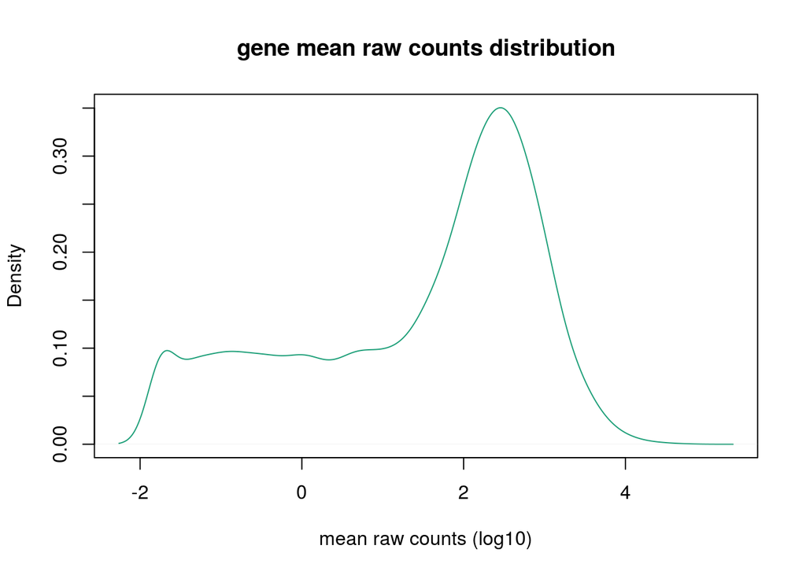

```r
plot(density(log10(rowMeans(kg))),col=pal[1],
     main="gene mean raw counts distribution",
     xlab="mean raw counts (log10)")
```

### 2.3.3 Display all samples raw counts distribution

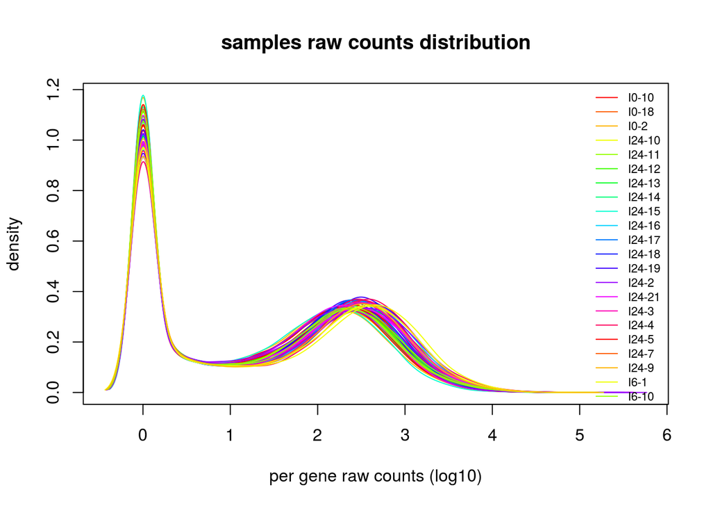

```r
plot.multidensity(log10(kg+1),
                  col=cols[as.integer(samples$Conditions)],
                  legend.x="topright",
                  legend=levels(samples$SampleName),
                  legend.col=cols,
                  legend.lwd=1,legend.cex=.7,
                  main="samples raw counts distribution",
                  xlab="per gene raw counts (log10)")
```

# 3 Data normalisation

For visualization, the data is submitted to a variance stabilization transformation using DESeq2. The dispersion is estimated independently of the sample type

```r
dds <- DESeqDataSetFromMatrix(
    countData = kg,
    colData = samples,
    design = ~ Conditions)
```

Check the size factors (i.e. the sequencing library size effect) There is no big variation, a Variance Stabilizing Transformation can be used (over a Relative Log Transformation)

```r
dds <- estimateSizeFactors(dds)
sizes <- sizeFactors(dds)
names(sizes) <- colnames(kg)
sizes
```

```
## P11554_138 P11554_139 P11554_140 P11554_141 P11554_142 P11554_143
##  0.6791229  0.6212473  0.7282292  1.2233397  0.8197929  0.9103346
## P11554_144 P11554_145 P11554_146 P11554_147 P11554_148 P11554_149
##  0.8943961  0.6034193  1.0062513  0.9309340  0.7244266  1.1268479
## P11554_150 P11554_151 P11554_152 P11554_153 P11554_154 P11554_155
##  1.1653073  0.8981852  0.8517850  0.8504145  0.8953430  0.9235755
## P11554_202 P11554_203 P11554_204 P11554_205 P11554_206 P11554_207
##  0.6877831  0.8913314  0.7234353  0.8956753  0.9896865  1.2818263
## P11554_208 P11554_209 P11554_210 P11554_211 P11554_212 P11554_213
##  1.0761254  0.8989956  0.9740292  1.4380392  1.1567124  0.9960962
## P11554_214 P11554_215 P11554_216 P11554_217 P11554_218 P11554_219
##  1.1913613  1.1338296  1.1179395  1.1851567  1.2878671  1.5164083
## P11554_220 P11554_221 P11554_222 P11554_223 P11554_224 P11554_225
##  1.1550124  1.2778943  1.3985854  1.0984968  1.1844090  0.7396800
## P11554_226 P11554_227 P11554_228 P11554_229 P11554_230 P11554_231
##  1.1011181  1.1397922  1.3290671  0.7615380  0.9274617  0.9493652
## P11554_232 P11554_233 P11554_234 P11554_235 P11554_236 P11554_237
##  0.7950453  0.8227029  1.4262241  1.6825429  1.4200308  1.2324292
```

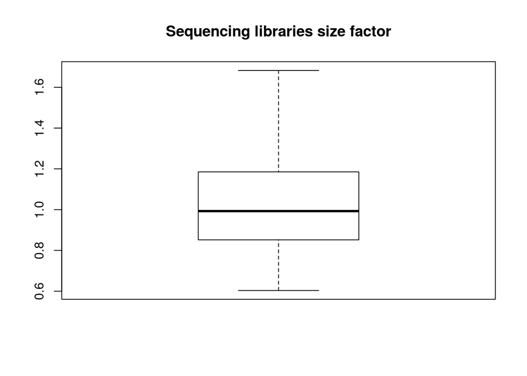

```r
boxplot(sizes, main="Sequencing libraries size factor")
```

split by batch effect

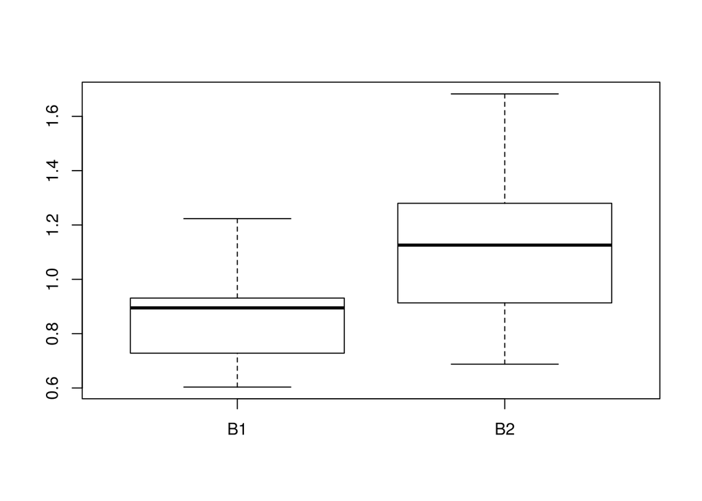

```r
boxplot(split(sizes,samples$Batch))
```

## 3.1 VST

```r
vsd <- varianceStabilizingTransformation(dds, blind=TRUE)
vst <- assay(vsd)
vst <- vst - min(vst)
```

Validation

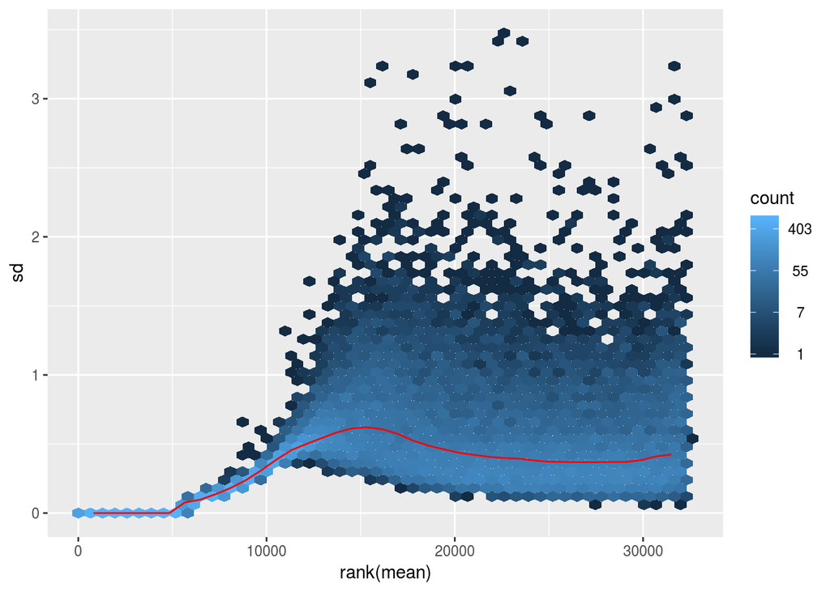

```r
meanSdPlot(vst)
```

Write out

```r
write.csv(vst,"/mnt/picea/projects/arabidopsis/jhanson/arabidopsis-nutrition-TOR/analysis_Tom/library-size-normalized_variance-stabilized_data_nutrition.csv")
```

## 3.2 Biological QA

### 3.2.1 MDS

Verification of the sample distribution by a multivariate approach on the raw data

- Samples

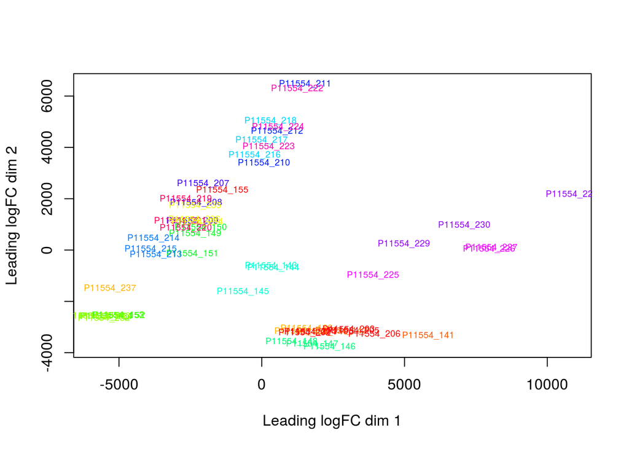

```r
plotMDS(kg,cex=.6,col=cols[as.integer(samples$Conditions)])
```

- Suspect samples

```r
suspect <- c("P11554_155","P11554_237")
sel <- samples$Conditions %in% samples[match(suspect,samples$SciLifeID),"Conditions"]
pander(samples[sel,])
```

Table continues below

|  | SciLifeID | SampleName | Timepoint | Nutrition | AZD | Conditions |
| --- | --- | --- | --- | --- | --- | --- |
| **97** | P11554_138 | J24-8 | 24 | NP | DMSO | 24_NP_DMSO |
| **98** | P11554_139 | I24-9 | 24 | NP | DMSO | 24_NP_DMSO |
| **114** | P11554_155 | I0-18 | 0 | T0 | 0 | 0_T0_0 |
| **2** | P11554_202 | J0-7 | 0 | T0 | 0 | 0_T0_0 |
| **3** | P11554_203 | J0-23 | 0 | T0 | 0 | 0_T0_0 |
| **4** | P11554_204 | J0-5 | 0 | T0 | 0 | 0_T0_0 |
| **5** | P11554_205 | J0-21 | 0 | T0 | 0 | 0_T0_0 |
| **6** | P11554_206 | J0-11 | 0 | T0 | 0 | 0_T0_0 |
| **37** | P11554_237 | I24-7 | 24 | NP | DMSO | 24_NP_DMSO |

|  | Batch |
| --- | --- |
| **97** | B1 |
| **98** | B1 |
| **114** | B1 |
| **2** | B2 |
| **3** | B2 |
| **4** | B2 |
| **5** | B2 |
| **6** | B2 |
| **37** | B2 |

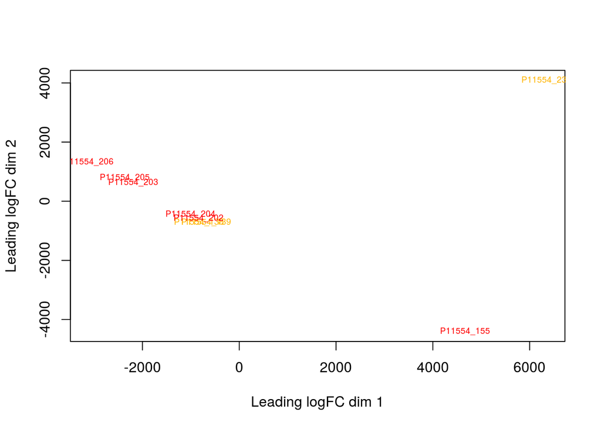

```r
plotMDS(kg[,sel],cex=.6,col=cols[as.integer(samples$Conditions)][sel])
```

- Suspect Batch

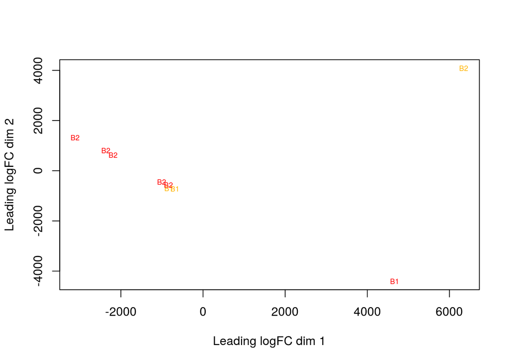

```r
plotMDS(kg[,sel],cex=.6,labels=samples$Batch[sel],col=cols[as.integer(samples$Conditions)][sel])
```

### 3.2.2 PCA

Principal Component Analysis on the normalized data

- Colour coded by Nutrition and AZD treatment - all data

```r
conditions1 <- factor(paste(samples$AZD,samples$Nutrition,sep="_"))
pch<-as.integer(factor(samples$Timepoint))+14
pc <- prcomp(t(vst))
percent <- round(summary(pc)$importance[2,]*100);percent
```

```
##  PC1  PC2  PC3  PC4  PC5  PC6  PC7  PC8  PC9 PC10 PC11 PC12 PC13 PC14 PC15
##   34   22   14    5    4    2    1    1    1    1    1    1    1    1    0
## PC16 PC17 PC18 PC19 PC20 PC21 PC22 PC23 PC24 PC25 PC26 PC27 PC28 PC29 PC30
##    0    0    0    0    0    0    0    0    0    0    0    0    0    0    0
## PC31 PC32 PC33 PC34 PC35 PC36 PC37 PC38 PC39 PC40 PC41 PC42 PC43 PC44 PC45
##    0    0    0    0    0    0    0    0    0    0    0    0    0    0    0
## PC46 PC47 PC48 PC49 PC50 PC51 PC52 PC53 PC54
##    0    0    0    0    0    0    0    0    0
```

- 0 hours

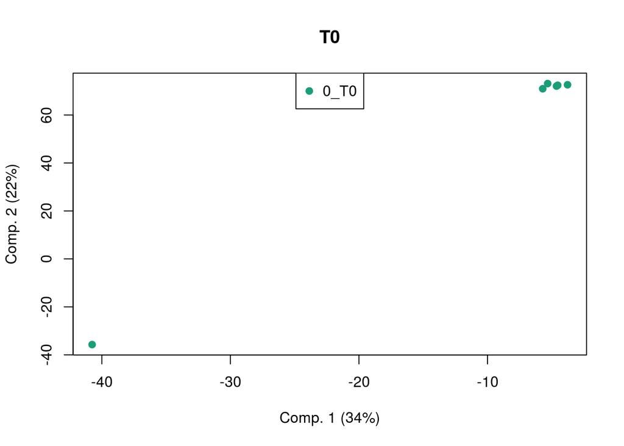

```r
t.sel <- samples$Timepoint == 0
conds <- droplevels(conditions1[t.sel])
plot(pc$x[t.sel,1],
     pc$x[t.sel,2],
     xlab=paste("Comp. 1 (",percent[1],"%)",sep=""),
     ylab=paste("Comp. 2 (",percent[2],"%)",sep=""),
     col=pal[as.integer(conds)],
     pch=19,main="T0")

legend("top",pch=19,
       col=pal[1:nlevels(conds)],
       legend=levels(conds))
```

- 6 hours

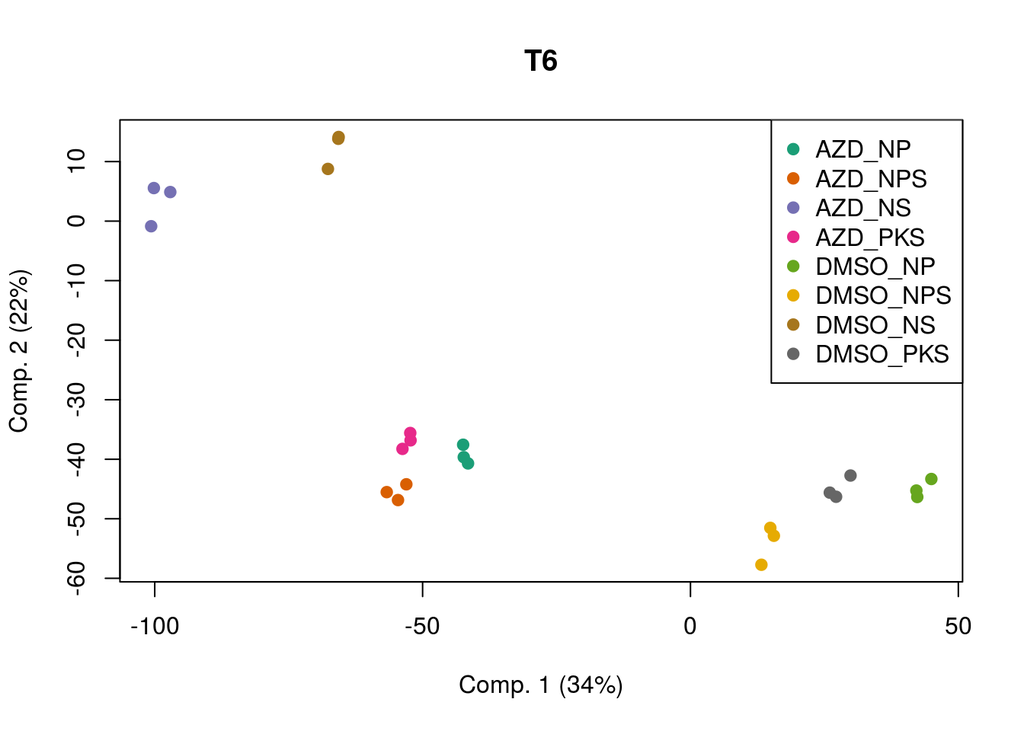

```r
t.sel <- samples$Timepoint == 6
conds <- droplevels(conditions1[t.sel])
plot(pc$x[t.sel,1],
     pc$x[t.sel,2],
     xlab=paste("Comp. 1 (",percent[1],"%)",sep=""),
     ylab=paste("Comp. 2 (",percent[2],"%)",sep=""),
     col=pal[as.integer(conds)],
     pch=19,main="T6")

legend("topright",pch=19,
       col=pal[1:nlevels(conds)],
       legend=levels(conds))
```

- 24 hours

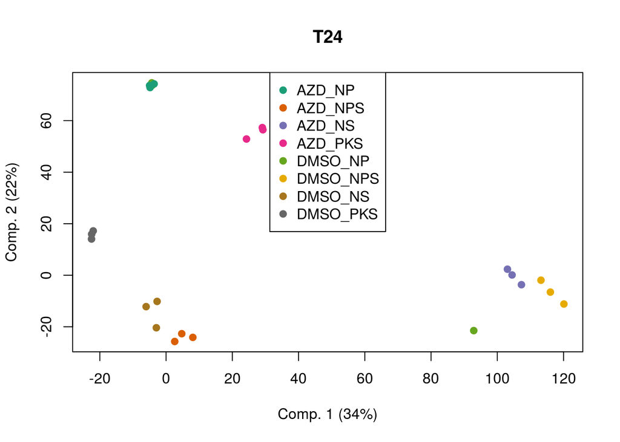

```r
t.sel <- samples$Timepoint == 24
conds <- droplevels(conditions1[t.sel])
plot(pc$x[t.sel,1],
     pc$x[t.sel,2],
     xlab=paste("Comp. 1 (",percent[1],"%)",sep=""),
     ylab=paste("Comp. 2 (",percent[2],"%)",sep=""),
     col=pal[as.integer(conds)],
     pch=19,main="T24")

legend("top",pch=19,
       col=pal[1:nlevels(conds)],
       legend=levels(conds))
```

Batch

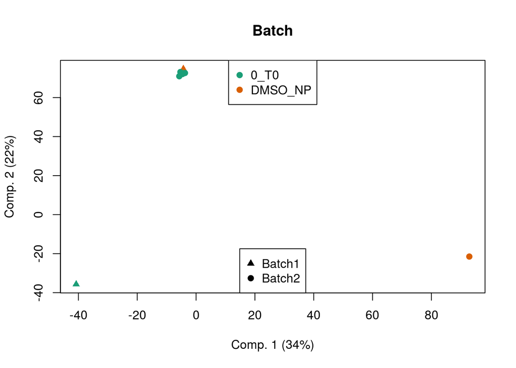

```r
conds <- droplevels(conditions1[sel])
plot(pc$x[sel,1],
     pc$x[sel,2],
     xlab=paste("Comp. 1 (",percent[1],"%)",sep=""),
     ylab=paste("Comp. 2 (",percent[2],"%)",sep=""),
     col=pal[as.integer(conds)],
     pch=c(17,19)[as.integer(samples$Batch)[sel]],
     main="Batch")

legend("bottom",pch=c(17,19),
       col="black",
       legend=c("Batch1","Batch2"))

legend("top",pch=19,
       col=pal[1:nlevels(conds)],
       legend=levels(conds))
```

Thawed

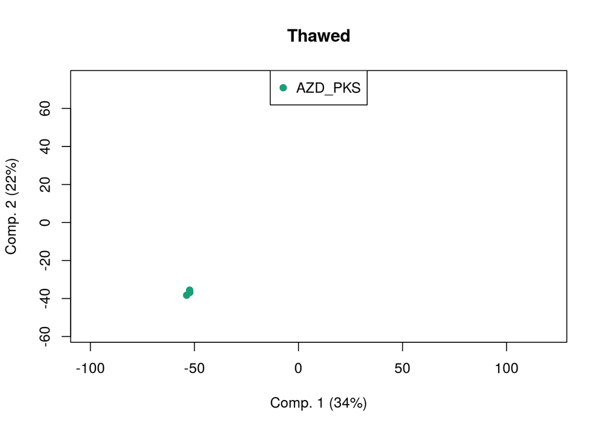

```r
t.sel <- samples$Conditions %in% samples$Conditions[samples$SciLifeID=="P11554_222"]
conds <- droplevels(conditions1[t.sel])
plot(pc$x[t.sel,1],
     pc$x[t.sel,2],
     xlim=range(pc$x[,1]),
     ylim=range(pc$x[,2]),
     xlab=paste("Comp. 1 (",percent[1],"%)",sep=""),
     ylab=paste("Comp. 2 (",percent[2],"%)",sep=""),
     col=pal[as.integer(conds)],
     pch=19,main="Thawed")

legend("top",pch=19,
       col=pal[1:nlevels(conds)],
       legend=levels(conds))
```